# GABA-AD: Effect of pharmacological activation of GABAARs

## **STUDY DESCRIPTION**

### Aim and hypothesis

The project aims to identify specific changes in our primary outcome measures (TMS-evoked potentials, TEPs) following the administration of alprazolam, a sedative acting on GABAA receptors in the brain.

When we administer alprazolam, the strength of GABAA-mediated neurotransmission in the whole brain increases. This augmentation will lead to changes in the reaction of the brain to the TMS stimulation of primary motor cortex (M1) and Angular gyrus (AG). We can measure brain’s reaction to TMS with TEPs, and we expect to see changes in these measures that will correspond to the increased GABAA neurotransmission. The size of this effect can be then used to assess the efficiency of the system.

Observed changes in TEPs can be therefore related to the state of GABAergic neurotransmission in the brain. In the follow-up study, these changes will be used as biomarkers to assess and compare the state of GABAergic neurotransmission within patient groups.

### Experimental design

20 subjects participated in 2 experimental sessions. Each session the same measures were taken at the baseline and after medication with either alprazolam or placebo.

In addition to TEPs, which represent our target outcome variable, we also recorded resting state EEG (RS-EEG) and extracted from it 4 pre-defined features. These variables are, according to the literature, sensitive to the activation of GABAergic system. Quantification of changes in these variables serves us to (1) verify the efficiency of sedation and (2) evaluate a possible correlation with the change in TEPs.

### Outcome variables

- **TEP peak amplitude**: measured separately for each TEP component (5 or 6 components) and stimulus (M1 TEPs sub- and supra-threshold, AG TEPs)
- **RS-EEG**: 4 DVs
  - mean power across the lower beta band = **sigma**
  - mean power across the delta band = **delta**
  - **Alpha Attenuation Coefficient** (eyes closed/eyes open)
  - **Spectral Exponent** of the 1/f slope

All outcome variables are measured at the baseline and after the medication (factors Time and Medication). However, since we are mainly interested in the interaction between Medication and Time, and to limit the influence of the individual amplitude of baseline TEPs, **the variables enter the analysis as the change introduced by the medication.** The change in TEP amplitude is calculated as a simple difference between the value post-medication and the value at baseline. RS-EEG variables are expressed as a percentual chnage.

### Fixed effect

- **MEDICATION**
  0. placebo = control condition
  1. amplrazolam
- Covariate: **rMT change** - continuous value

### Random effect

- random intercept for each **SUBJECT**

## **STATISTICAL ANALYSIS**

**Following pipeline treats each outcome measure separately, as an independent measure.**

### Import data

Choose a .csv file with either TEP or rsEEG data.

```r
# import the data
input_file <- choose.files(default = folder_dir, caption = "Select the dataset")
data_all <- as_tibble(read.csv(input_file))
names(data_all)
```

```
[1] "subject"    "medication" "time"       "delta"      "sigma"      "AAC"        "SE"
```

```r
summary(data_all)
```

```
    subject       medication            time               delta            sigma             AAC               SE
 Min.   : 1.00   Length:120         Length:120         Min.   :-10.24   Min.   :-17.68   Min.   :-77.05   Min.   :-1.470
 1st Qu.: 5.75   Class :character   Class :character   1st Qu.:  0.18   1st Qu.:  0.07   1st Qu.: -8.42   1st Qu.:-1.087
 Median :10.50   Mode  :character   Mode  :character   Median :  0.23   Median :  0.10   Median :  1.08   Median :-0.878
 Mean   :10.50                                         Mean   :  5.96   Mean   : 11.48   Mean   : -7.10   Mean   :-0.722
 3rd Qu.:15.25                                         3rd Qu.:  0.62   3rd Qu.:  8.39   3rd Qu.:  1.63   3rd Qu.:-0.227
 Max.   :20.00                                         Max.   :104.67   Max.   :140.20   Max.   : 67.31   Max.   : 0.263
```

### Variable of interest

```r
data_type
```

```
[1] "rsEEG"
```

### Descriptive statistics

The distribution is described and visualized for both levels of the factor ‘medication’ separately. The normality is checked both visually (histogram, QQ-plot) and using the Shapiro-Wilk normality test.

```r
# ---- DISTRIBUTION ----
# get summary per medication
data %>%
  select(c(DV_change, medication)) %>%
  group_by(medication) %>%
  skim()
```

```
-- Data Summary ------------------------
                           Values
Name                       Piped data
Number of rows             40
Number of columns          2
_______________________
Column type frequency:
  numeric                  1
________________________
Group variables            medication

-- Variable type: numeric -----------------------------------------------------------------------------------------------------
# A tibble: 2 x 12
  skim_variable medication n_missing complete_rate  mean    sd    p0   p25   p50    p75  p100 hist
* <chr>         <ord>          <int>         <dbl> <dbl> <dbl> <dbl> <dbl> <dbl>  <dbl> <dbl> <chr>
1 DV_change     placebo            0             1 -14.4  26.8 -44.9 -30.8 -19.4  -2.08 67.3  ▇▅▃▁▁
2 DV_change     alprazolam         0             1 -34.4  22.8 -77.0 -45.7 -31.2 -17.2   6.40 ▅▂▇▆▂
```

```r
# calculate mean values
data_mean <- data %>%
  group_by(medication) %>%
  summarise(mean = mean(DV_change), sd = sd(DV_change), sem = sd(DV_change)/sqrt(20), median = median(DV_change))
data_mean %>%
  knitr::kable()
```

| medication | mean | sd | sem | median |
| --- | --- | --- | --- | --- |
| placebo | -14.37 | 26.80 | 5.993 | -19.42 |
| alprazolam | -34.43 | 22.82 | 5.103 | -31.22 |

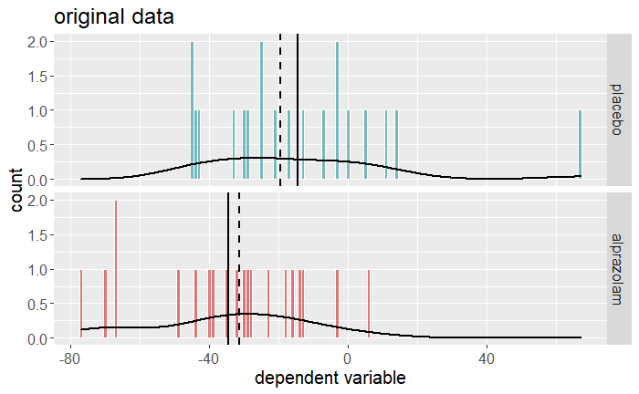

```r
# plot by mediation
data %>%
  ggplot(aes(x = DV_change, y = ..count.., fill = medication)) +
  geom_histogram(binwidth = 1, col = 'white', alpha = 0.5) +
  geom_density(alpha = 0, size = 1) +
  facet_grid(medication ~ .) +
  geom_vline(data = data_mean, aes(xintercept = median), linetype = 'dashed', size = 1) +
  geom_vline(data = data_mean, aes(xintercept = mean), size = 1) +
  ggtitle('original data') +
  ylab('count') +
  xlab('dependent variable') +
  theme(text = element_text(size = 15), legend.position = 'none') +
  scale_fill_manual(values = col_palette[c(2, 4)])
```

```r
# skewness and kurtosis
data_shape <- data %>%
  group_by(medication) %>%
  summarise(skewness = skewness(DV_change), kurtosis = kurtosis(DV_change))
data_shape %>%
  knitr::kable()
```

| medication | skewness | kurtosis |
| --- | --- | --- |
| placebo | 1.3271 | 5.284 |
| alprazolam | -0.2997 | 2.340 |

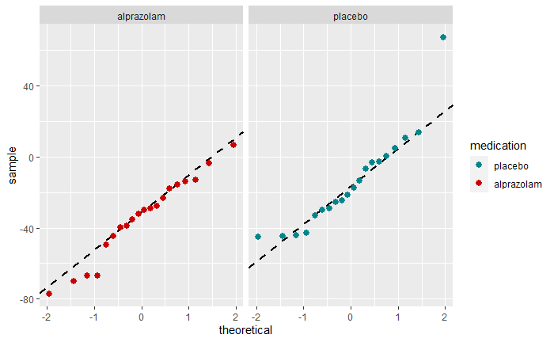

```r
# ---- NORMALITY TEST ----
# parameters for the fitted line
slopes <- numeric()
ints <- numeric()
for(i in levels(factor(data$medication))) {
  slopes[i] <- diff(quantile(data$DV_change[data$medication == i],
                            probs = c(0.25, 0.75))) / diff(qnorm(c(0.25, 0.75)))
  ints[i] <- quantile(data$DV_change[data$medication == i],
                     probs = c(0.25)) - slopes[i] * qnorm(c(0.25))
}
params <- data.frame(medication = levels(data$medication),
                     a = slopes,
                     b = ints)
rm(slopes, ints)

# QQ-plot
data %>%
  ggplot(aes(sample = DV_change, col = medication)) +
  geom_abline(data = params %>% group_by(medication),
              aes(slope = a, intercept = b), lwd = 1, lty = 2, color = 'black') +
  geom_qq(size = 2.5) +
  facet_grid(. ~ medication) +
  scale_color_manual(values = col_palette[c(2, 4)])
```

```r
# Shapiro-Wilk test
data %>%
  group_by(medication) %>%
  shapiro_test(DV_change)
```

| medication | variable | statistic | p |
| --- | --- | --- | --- |
| placebo | DV_change | 0.8814 | 0.01879 |
| alprazolam | DV_change | 0.9631 | 0.60764 |

```r
NA
```

### Data transformation

Transformations are applied only when needed - in the case of a non-normal distribution. The code below tests two possible transformations - square root and log transform with the base 2 - and their effect on the final distribution.

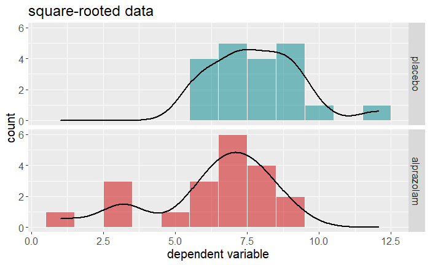

```r
# constants --> onset to positive values
c <- -min(data$DV_change) + 1
data_trans <- data %>%
  # filter(!(subject %in% remove_subj)) %>%
  mutate(DV_change = DV_change + c)

# reflect if negatively skewed
# data_trans <- data_trans %>%
#   group_by(medication) %>%
#   mutate(DV_change = max(data_trans$DV_change) - DV_change + 1)

# ---- SQUARE ROOT ----
# create new variable
data_trans <- data_trans %>%
  mutate(DV_sqrt = sqrt(DV_change))

# plot by mediation
data_trans %>%
  ggplot(aes(x = DV_sqrt, y = ..count.., fill = medication)) +
  geom_histogram(binwidth = 1, col = 'white', alpha = 0.5) +
  geom_density(alpha = 0, size = 1) +
  facet_grid(medication ~ .) +
  ggtitle('square-rooted data') +
  ylab('count') +
  xlab('dependent variable') +
  theme(text = element_text(size = 15), legend.position = 'none') +
  scale_fill_manual(values = col_palette[c(2, 4)])
```

```r
# Shapiro-Wilk test
data_trans %>%
  group_by(medication) %>%
  shapiro_test(DV_sqrt)
```

| medication | variable | statistic | p |
| --- | --- | --- | --- |
| placebo | DV_sqrt | 0.9355 | 0.19732 |
| alprazolam | DV_sqrt | 0.9016 | 0.04413 |

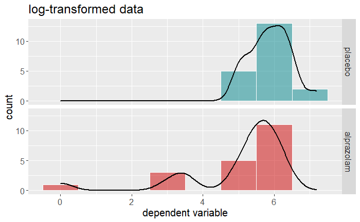

```r
# ---- LOG TRANSFORM ----
# create new variable
data_trans <- data_trans %>%
  mutate(DV_log2 = log2(DV_change))

# plot by mediation
data_trans %>%
  ggplot(aes(x = DV_log2, y = ..count.., fill = medication)) +
  geom_histogram(binwidth = 1, col = 'white', alpha = 0.5) +
  geom_density(alpha = 0, size = 1) +
  facet_grid(medication ~ .) +
  ggtitle('log-transformed data') +
  ylab('count') +
  xlab('dependent variable') +
  theme(text = element_text(size = 15), legend.position = 'none') +
  scale_fill_manual(values = col_palette[c(2, 4)])
```

```r
# Shapiro-Wilk test
data_trans %>%
  group_by(medication) %>%
  shapiro_test(DV_log2)
```

| medication | variable | statistic | p |
| --- | --- | --- | --- |
| placebo | DV_log2 | 0.9570 | 0.4857583 |
| alprazolam | DV_log2 | 0.7328 | 0.0001007 |

### Outlier rejection

If a serious outlier is identified, the subject might be removed from the dataset. This step is an option if transformations don’t prove helpful.

```r
# outlier threshold
out_threshold <- data %>%
  group_by(medication) %>%
  summarize(a = quantile(DV_change, 0.75) - 1.5*IQR(DV_change), b = quantile(DV_change, 0.75) + 1.5*IQR(DV_change))
out_threshold %>%
  knitr::kable()
```

| medication | a | b |
| --- | --- | --- |
| placebo | -45.11 | 40.96 |
| alprazolam | -59.91 | 25.42 |

```r
# idenntify outliers
outliers <- boxplot.stats(data %>% group_by(medication) %>% pull(DV_change))$out
outliers_index <- which(data %>% group_by(medication) %>% pull(DV_change) %in% c(outliers))
data[outliers_index,]
```

| subject | medication | DV_change |
| --- | --- | --- |
| 15 | placebo | 67.31 |

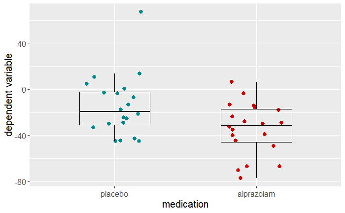

```r
# boxplot
data %>%
  ggplot(aes(medication, DV_change, col = medication)) +
  geom_jitter(width = 0.2, size = 2.5, show.legend = FALSE) +
  scale_color_manual(values = col_palette[c(2, 4)]) +
  geom_boxplot(col = 'black', alpha = 0, width = 0.5) +
  ylab('dependent variable') +
  xlab('medication') +
  theme(text = element_text(size = 15))
```

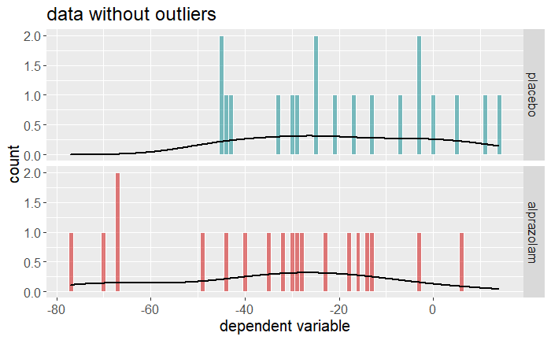

```r
# choose which outliers to remove
remove_subj <- data$subject[outliers_index[c(1)]]

# plot by medication
data %>%
  filter(!(subject %in% remove_subj)) %>%
  ggplot(aes(x = DV_change, y = ..count.., fill = medication)) +
  geom_histogram(binwidth = 1, col = 'white', alpha = 0.5) +
  geom_density(alpha = 0, size = 1) +
  facet_grid(medication ~ .) +
  ggtitle('data without outliers') +
  ylab('count') +
  xlab('dependent variable') +
  theme(text = element_text(size = 15), legend.position = 'none') +
  scale_fill_manual(values = col_palette[c(2, 4)])
```

```r
# Shapiro-Wilk test
data %>%
  filter(!(subject %in% remove_subj)) %>%
  group_by(medication) %>%
  shapiro_test(DV_change)
```

| medication | variable | statistic | p |
| --- | --- | --- | --- |
| placebo | DV_change | 0.9417 | 0.2826 |
| alprazolam | DV_change | 0.9575 | 0.5250 |

```r
NA
```

### Build models and compare

Based on the previous exploration, choose appropriate adjustment to the data.

```r
# choose transformation if necessary
trans <- readline(prompt = "Use transformation: ")
none
if(trans == 'sqrt'){
  data <- data %>%
    mutate(DV_model = data_trans$DV_sqrt)
}
if(trans == 'log'){
  data <- data %>%
  mutate(DV_model = data_trans$DV_log2)
}
if(trans == 'none'){
  data <- data %>%
  mutate(DV_model = DV_change)
}

# remove outliers if necessary
out <- askYesNo('Do you want to filter out ouliers?')
if(out){
  data <- filter(data, !subject %in% remove_subj)
}

# center the covariate (TEPs only)
if(data_type == 'TEP'){
  rMT_centered <- vector()
  for(i in 1:length(data$rMT)){
    if(data$medication[i] == 'placebo'){
      rMT_centered[i] <- data$rMT[i] - mean(data$rMT[data$medication == 'placebo'])
    }
    if(data$medication[i] == 'alprazolam'){
      rMT_centered[i] <- data$rMT[i] - mean(data$rMT[data$medication == 'alprazolam'])
    }
  }
  data$rMT_centered <- rMT_centered
}
```

Model n. 1: simple linear regression without random effects

```r
model_lm <- lm(DV_model ~ medication,
  data = data
)
summary(model_lm)
```

```
Call:
lm(formula = DV_model ~ medication, data = data)

Residuals:
   Min     1Q Median     3Q    Max
-42.62 -15.08   0.19  15.28  81.68

Coefficients:
             Estimate Std. Error t value Pr(>|t|)
(Intercept)    -24.40       3.94   -6.20    3e-07 ***
medication.L   -14.18       5.57   -2.55    0.015 *
---
Signif. codes:  0 ‘***’ 0.001 ‘**’ 0.01 ‘*’ 0.05 ‘.’ 0.1 ‘ ’ 1

Residual standard error: 24.9 on 38 degrees of freedom
Multiple R-squared:  0.146, Adjusted R-squared:  0.123
F-statistic: 6.49 on 1 and 38 DF,  p-value: 0.015
```

```r
confint(model_lm)
```

```
              2.5 %  97.5 %
(Intercept)  -32.37 -16.435
medication.L -25.45  -2.917
```

Model n. 2: empty model with random intercept

```r
model_ri <- lmer(
  DV_model ~ 1 + (1|subject),
  data = data
)
summary(model_ri)
```

```
Linear mixed model fit by REML. t-tests use Satterthwaite's method ['lmerModLmerTest']
Formula: DV_model ~ 1 + (1 | subject)
   Data: data

REML criterion at convergence: 370

Scaled residuals:
   Min     1Q Median     3Q    Max
-1.807 -0.485 -0.050  0.510  3.342

Random effects:
 Groups   Name        Variance Std.Dev.
 subject  (Intercept)  82.6     9.09
 Residual             626.3    25.03
Number of obs: 40, groups:  subject, 20

Fixed effects:
            Estimate Std. Error     df t value Pr(>|t|)
(Intercept)   -24.40       4.45  19.00   -5.49  2.7e-05 ***
---
Signif. codes:  0 ‘***’ 0.001 ‘**’ 0.01 ‘*’ 0.05 ‘.’ 0.1 ‘ ’ 1
```

```r
confint(model_ri)
```

```
Computing profile confidence intervals ...
```

```
             2.5 % 97.5 %
.sig01        0.00  21.52
.sigma       18.90  33.07
(Intercept) -33.32 -15.48
```

Model n. 3: predictor variables + random intercept

```r
if(data_type == 'TEP'){
  model_rip <- lmer(
    DV_model ~ medication + rMT_centered + (1|subject),
    data = data
  )
}else{
  model_rip <- lmer(
    DV_model ~ medication + (1|subject),
    data = data
  )
}
summary(model_rip)
```

```
Linear mixed model fit by REML. t-tests use Satterthwaite's method ['lmerModLmerTest']
Formula: DV_model ~ medication + (1 | subject)
   Data: data

REML criterion at convergence: 357.3

Scaled residuals:
    Min      1Q  Median      3Q     Max
-1.3206 -0.6725  0.0903  0.5298  3.0669

Random effects:
 Groups   Name        Variance Std.Dev.
 subject  (Intercept) 172      13.1
 Residual             447      21.2
Number of obs: 40, groups:  subject, 20

Fixed effects:
             Estimate Std. Error     df t value Pr(>|t|)
(Intercept)    -24.40       4.45  19.00   -5.49  2.7e-05 ***
medication.L   -14.18       4.73  19.00   -3.00   0.0074 **
---
Signif. codes:  0 ‘***’ 0.001 ‘**’ 0.01 ‘*’ 0.05 ‘.’ 0.1 ‘ ’ 1

Correlation of Fixed Effects:
            (Intr)
medicatin.L 0.000
```

```r
confint(model_rip)
```

```
Computing profile confidence intervals ...
```

```
              2.5 %  97.5 %
.sig01         0.00  23.464
.sigma        15.57  28.956
(Intercept)  -33.32 -15.479
medication.L -23.67  -4.696
```

```r
anova(model_ri, model_rip)
```

```
refitting model(s) with ML (instead of REML)
```

```
Data: data
Models:
model_ri: DV_model ~ 1 + (1 | subject)
model_rip: DV_model ~ medication + (1 | subject)
          npar AIC BIC logLik deviance Chisq Df Pr(>Chisq)
model_ri     3 381 386   -187      375
model_rip    4 375 382   -184      367  7.75  1     0.0054 **
---
Signif. codes:  0 ‘***’ 0.001 ‘**’ 0.01 ‘*’ 0.05 ‘.’ 0.1 ‘ ’ 1
```

Describe the full model using the nlme package in order to extract the p-value of the predictor.

```r
# choose the model to retain
if(data_type == 'TEP'){
  model <- lme(
    DV_model ~ medication + rMT_centered,
    random = ~ 1|subject,
    data = data,
    method = 'ML'
  )
}else{
  model <- lme(
    DV_model ~ medication,
    random = ~ 1|subject,
    data = data,
    method = 'ML'
  )
}

# fixed effects
broom.mixed::tidy(model, effects = 'fixed') %>%
  knitr::kable()
```

| term | estimate | std.error | df | statistic | p.value |
| --- | --- | --- | --- | --- | --- |
| (Intercept) | -24.40 | 4.449 | 19 | -5.485 | 0.0000 |
| medication.L | -14.18 | 4.730 | 19 | -2.998 | 0.0074 |

```r
# fixed effects
broom.mixed::tidy(model, effects = 'ran_pars') %>%
  knitr::kable()
```

| effect | group | term | estimate |
| --- | --- | --- | --- |
| ran_pars | subject | sd_(Intercept) | 12.78 |
| ran_pars | Residual | sd_Observation | 20.62 |

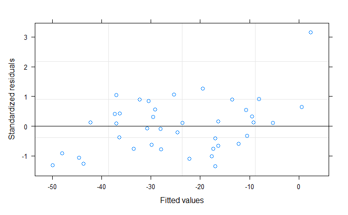

```r
# residuals
plot(model)
```

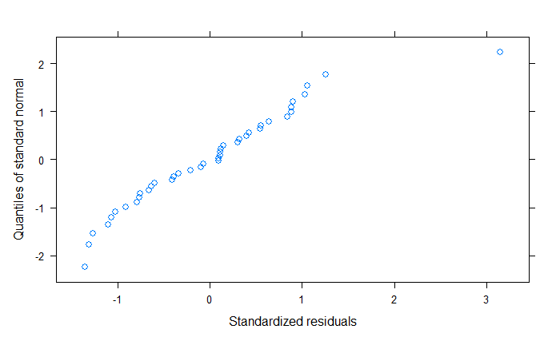

```r
qqnorm(model)
```

Estimate p values using the Kenward-Roger approximation

```r
anova(model_rip, ddf="Kenward-Roger") %>%
  knitr::kable()
```

|  | Sum Sq | Mean Sq | NumDF | DenDF | F value | Pr(>F) |
| --- | --- | --- | --- | --- | --- | --- |
| medication | 4023 | 4023 | 1 | 19 | 8.991 | 0.0074 |

## **MODEL INTERPRETATION & QUESTIONS**

I am mostly interested in the fixed effect of medication. However, as the inter-subject variability is often very high in EEG derived variables, I am including it by adding the random intercept for a subject. In case of TEP variables, I also include the change of RMT as a covariate (it can acquire a different value, positive or negative, in one subject across sessions).

When reporting the results, I would therefore focus mainly on fixed effects. Using the example variable, I would formulate my interpretation as follows: *A linear mixed effects model was used to evaluate the effect of medication on the change of amplitude of the TEP component N100. Random intercept was included to account for the within subjects design and the change of rMT was added as a covariate. The results show significant effect of medication (Estimate = 0.35, SE = 0.128, p = 0.018). The effect of the rMT change was not significant.*

However, I am not sure how to report and explain the great significance at the intercept. Does that mean that after placebo the change in amplitude is also significant (= significantly different from 0), however it is greater after alprazolam..?

And how do I report random effects, that show very small variance and confidence intervals including 0..?

I am also not sure hohw to correct the significance levels. Should I use Bonferonni correction for each group of variables, for example if I test M1 TEPs that have 6 components, should I devide alpha by 6..?